### Data:

```r
load(url("http://bit.ly/dasi_nc"))
load(url("http://bit.ly/dasi_gss_ws_cl"))
```

There are 1,000 cases in this data set, what do the cases represent?

1. The hospitals where the births took place
2. The fathers of the children
3. The days of the births
4. The births

answer: D

How many mothers are we missing weight gain data from?

1. 0
2. 13
3. 27
4. 31

answer: c

```r
gained_clean=na.omit(nc$gained)
n = length(gained_clean)
```

# The Bootstrap

```r
boot_means = rep(NA, 100)

for(i in 1:100){
  boot_sample = sample(gained_clean, n, replace = TRUE)
  boot_means[i] = mean(boot_sample)
}
```

True / False: The sampling distribution is calculated by resampling from the population, the bootstrap distribution is calculated by resampling from the sample.

1. True
2. False

answer: a

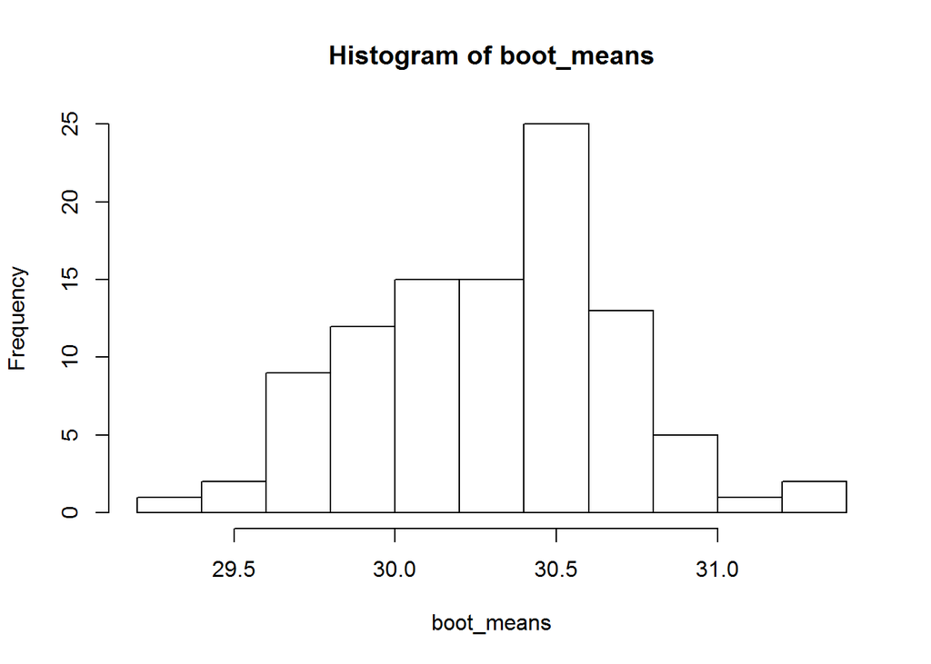

```r
hist(boot_means)
```

True / False: To construct the 95% bootstrap confidence interval using the percentile method, we estimate the values of the 5th5th and 95th95th percentiles of the bootstrap distribution.

1. True
2. False

answer: b

Exercise: Estimate a 90% confidence interval using the percentile method for the average weight gained by mothers during pregnancy, explain briefly how you estimated the interval, and interpret this interval in context of the data.

```r
zvalue<-qnorm(.95)
range=zvalue*sd(gained_clean)
confidece_interval_gained=c(mean(gained_clean)-range,mean(gained_clean)+range)
```

# Bootstrap

```r
se=sd(gained_clean)/sqrt(length(boot_means))
range_bootmeans=zvalue*se
confidece_interval_bootmeans=c(mean(boot_means)-se,mean(boot_means)+se)
```

# The Inference Function

```r
source("http://bit.ly/dasi_inference")
```

By default the function takes 10,000 bootstrap samples (instead of the 100 you’ve taken above), creates a bootstrap distribution, and calculates the confidence interval, using the percentile method.

```r
inference(nc$gained, type = "ci", method = "simulation", conflevel = 0.90, est = "mean", boot_method = "perc")
```

```
## Single mean
## Summary statistics:
```

```
## mean = 30.3258 ;  sd = 14.2413 ;  n = 973
```

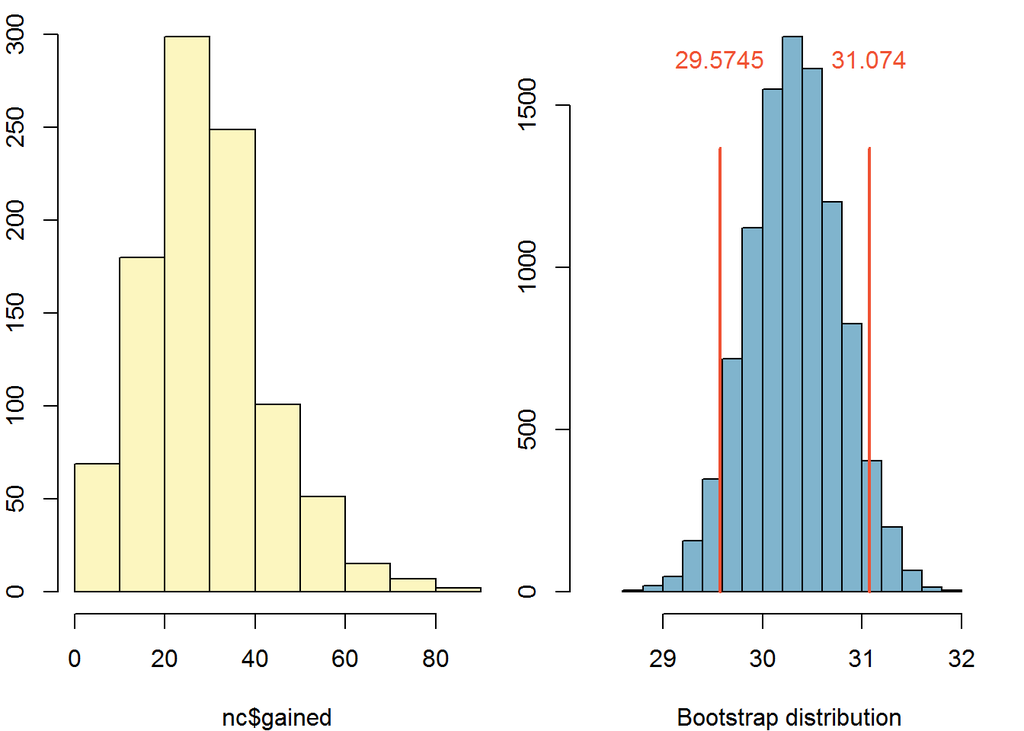

```
## Bootstrap method: Percentile
## 90 % Bootstrap interval = ( 29.5745 , 31.074 )
```

We can easily change the confidence level to 95% by changing the conflevel:

```r
inference(nc$gained, type = "ci", method = "simulation", conflevel = 0.95, est = "mean", boot_method = "perc")
```

```
## Single mean
## Summary statistics:
```

```
## mean = 30.3258 ;  sd = 14.2413 ;  n = 973
```

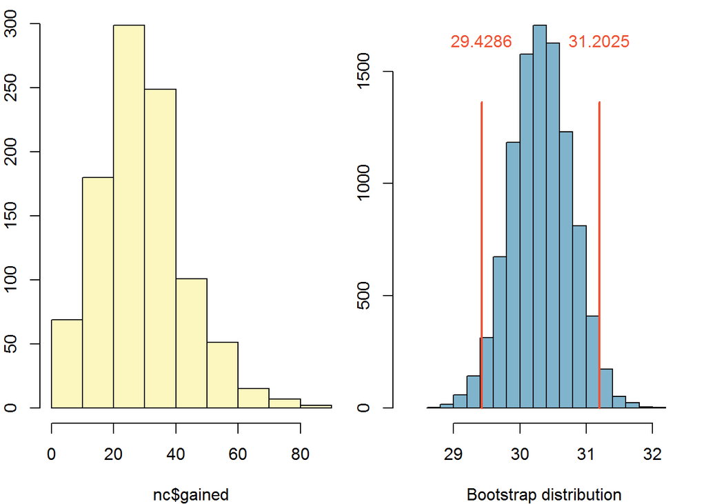

```
## Bootstrap method: Percentile
## 95 % Bootstrap interval = ( 29.4286 , 31.2025 )
```

We can easily use the standard error method by changing the boot_method:

```r
inference(nc$gained, type = "ci", method = "simulation", conflevel = 0.95, est = "mean", boot_method = "se")
```

```
## Single mean
## Summary statistics:
```

```
## mean = 30.3258 ;  sd = 14.2413 ;  n = 973
```

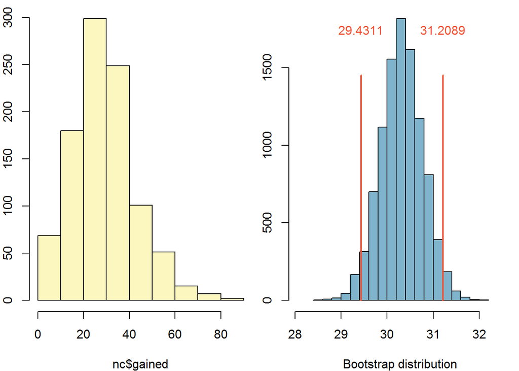

```
## Bootstrap method: Standard error; Boot. mean = 30.32 ; Boot. SE = 0.4535
## 95 % Bootstrap interval = ( 29.4311 , 31.2089 )
```

Or create an interval for the median instead of the mean:

```r
inference(nc$gained, type = "ci", method = "simulation", conflevel = 0.95, est = "median", boot_method = "se")
```

```
## Single median
## Summary statistics:
```

```
## median = 30 ;  n = 973
```

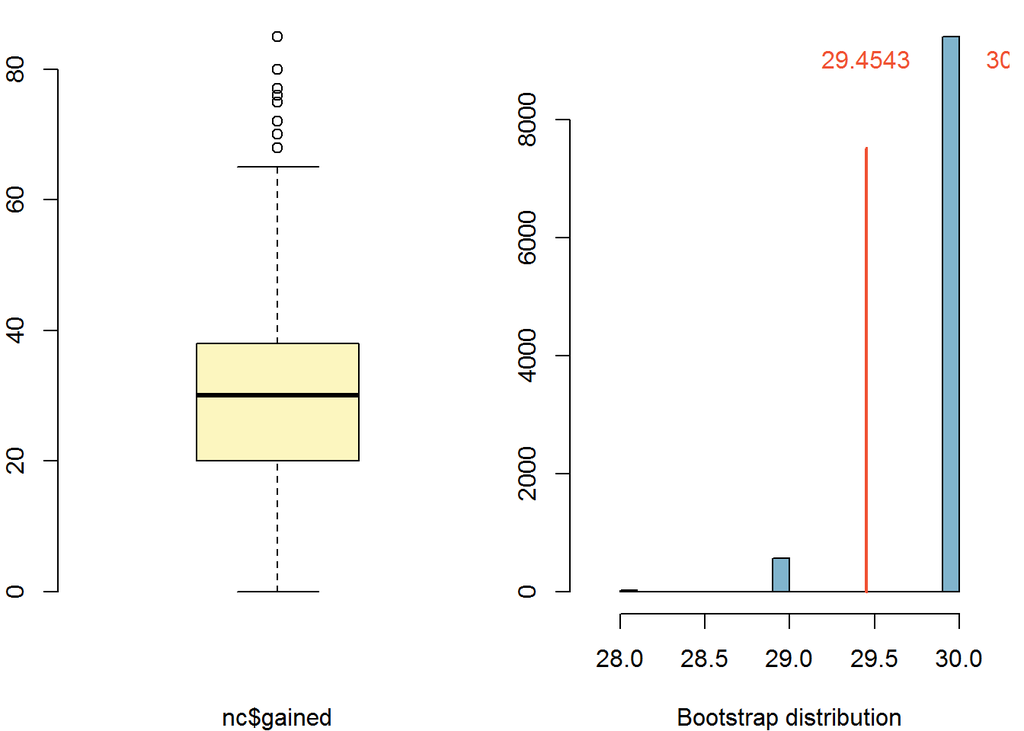

```
## Bootstrap method: Standard error; Boot. mean = 29.9393 ; Boot. SE = 0.2474
## 95 % Bootstrap interval = ( 29.4543 , 30.4243 )
```

True / False: The bootstrap distribution of the median weight gain is a smooth, unimodal, symmetric distribution that yields a reliable confidence interval estimate.

1. True
2. False

answer: b

Exercise: Create a 95% bootstrap confidence interval for the mean age of fathers at the birth of their child, nc$fage, using the standard error method. Interpret the interval within the context of the data.

```r
inference(nc$fage, type = "ci", method = "simulation", conflevel = 0.95, est = "mean", boot_method = "se")
```

```
## Single mean
## Summary statistics:
```

```
## mean = 30.2557 ;  sd = 6.7638 ;  n = 829
```

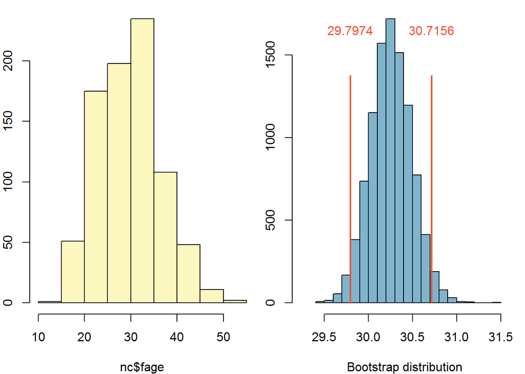

```
## Bootstrap method: Standard error; Boot. mean = 30.2565 ; Boot. SE = 0.2342
## 95 % Bootstrap interval = ( 29.7974 , 30.7156 )
```

Based on the plot from the previous exercise, which of the following is false about the relationship between habit and weight?

1. Median birth weight of babies born to non-smoker mothers is slightly higher than that of babies born to smoker mothers.
2. Range of birth weights of babies born to non-smoker mothers is greater than that of babies born to smoker mothers.
3. Both distributions are slightly right skewed.
4. The IQRs of the distributions are roughly equal.

answer: c

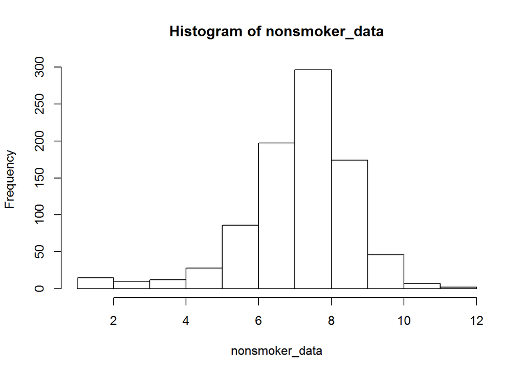

```r
nonsmoker_data<-nc[which(nc$habit=="nonsmoker"),"weight"]
smoker_data<-nc[which(nc$habit=="smoker"),"weight"]

hist(nonsmoker_data)
```

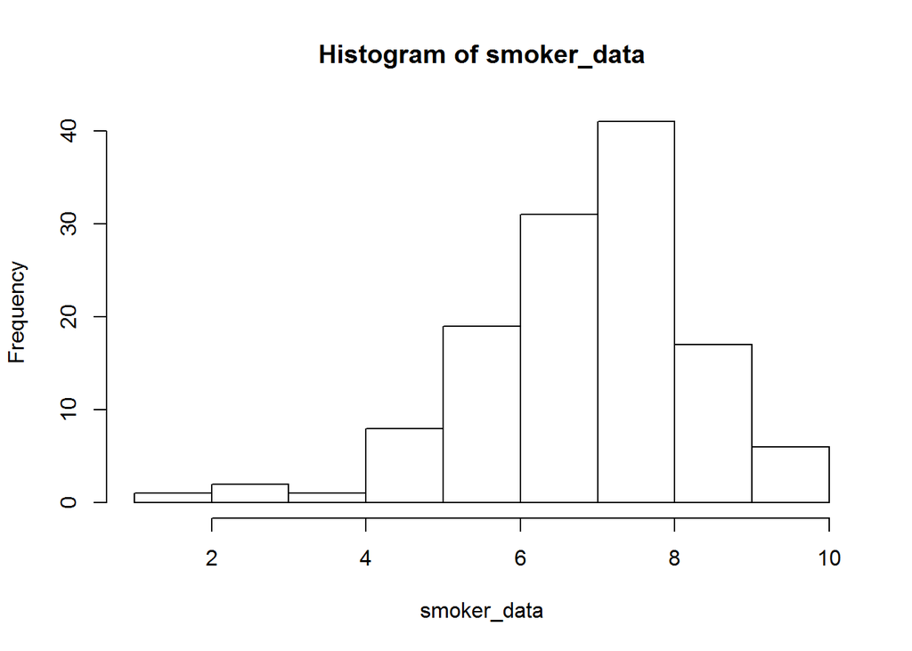

```r
hist(smoker_data)
```

```r
#getting the mean
by(nc$weight, nc$habit, mean)
```

```
## nc$habit: nonsmoker
## [1] 7.144273
## --------------------------------------------------------
## nc$habit: smoker
## [1] 6.82873
```

```r
inference(y = nc$weight, x = nc$habit, est = "mean", type = "ht", null = 0, alternative = "twosided", method = "theoretical")
```

```
## Response variable: numerical, Explanatory variable: categorical
## Difference between two means
## Summary statistics:
## n_nonsmoker = 873, mean_nonsmoker = 7.1443, sd_nonsmoker = 1.5187
## n_smoker = 126, mean_smoker = 6.8287, sd_smoker = 1.3862
```

```
## Observed difference between means (nonsmoker-smoker) = 0.3155
## H0: mu_nonsmoker - mu_smoker = 0
## HA: mu_nonsmoker - mu_smoker != 0
## Standard error = 0.134
## Test statistic: Z =  2.359
## p-value =  0.0184
```

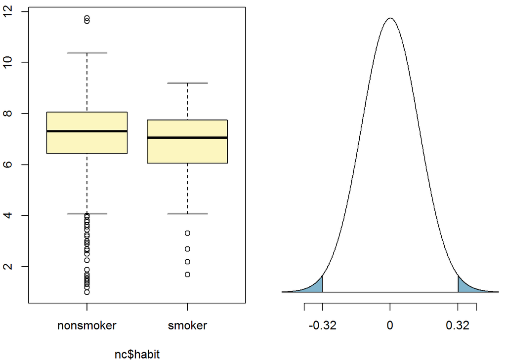

```r
inference(y = nc$weight, x = nc$habit, est = "mean", type = "ht", null = 0, alternative = "twosided", method = "theoretical", order = c("smoker","nonsmoker"))
```

```
## Response variable: numerical, Explanatory variable: categorical
## Difference between two means
## Summary statistics:
## n_smoker = 126, mean_smoker = 6.8287, sd_smoker = 1.3862
## n_nonsmoker = 873, mean_nonsmoker = 7.1443, sd_nonsmoker = 1.5187
```

```
## Observed difference between means (smoker-nonsmoker) = -0.3155
## H0: mu_smoker - mu_nonsmoker = 0
## HA: mu_smoker - mu_nonsmoker != 0
## Standard error = 0.134
## Test statistic: Z =  -2.359
## p-value =  0.0184
```

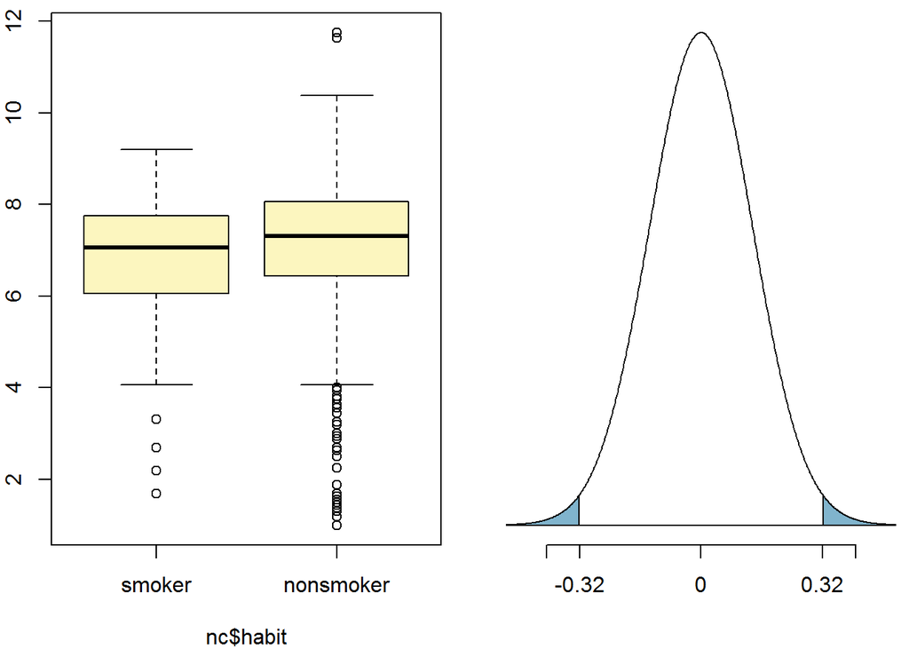

Change the type argument to “ci” to construct and record a confidence interval for the difference between the weights of babies born to smoking and non-smoking mothers. Which of the following is the best interpretation of the interval?

1. We are 95% confident that babies born to nonsmoker mothers are on average 0.05 to 0.58 pounds heavier at birth than babies born to smoker mothers.
2. We are 95% confident that babies born to nonsmoker mothers are on average 0.05 to 0.58 pounds lighter at birth than babies born to smoker mothers.
3. We are 95% confident that the difference in average weights of babies whose moms are smokers and nonsmokers is between 0.05 to 0.58 pounds.
4. We are 95% confident that the difference in average weights of babies in this sample whose moms are smokers and nonsmokers is between 0.05 to 0.58 pounds.

```r
inference(y = nc$weight, x = nc$habit, est = "mean", type = "ci", null = 0, alternative = "twosided", method = "theoretical", order = c("smoker","nonsmoker"))
```

```
## Response variable: numerical, Explanatory variable: categorical
## Difference between two means
## Summary statistics:
## n_smoker = 126, mean_smoker = 6.8287, sd_smoker = 1.3862
## n_nonsmoker = 873, mean_nonsmoker = 7.1443, sd_nonsmoker = 1.5187
```

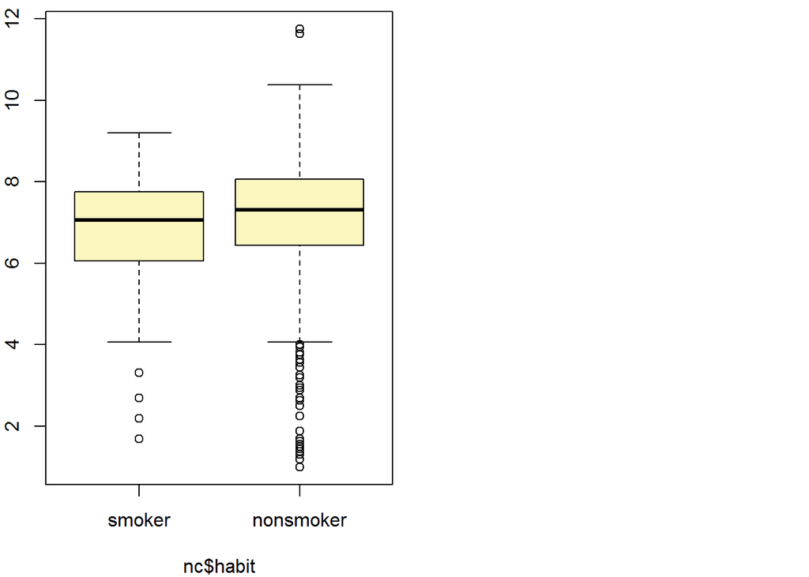

```
## Observed difference between means (smoker-nonsmoker) = -0.3155
## Standard error = 0.1338
## 95 % Confidence interval = ( -0.5777 , -0.0534 )
```

Now, a non-inference task: Determine the age cutoff for younger and mature mothers. Use a method of your choice. What is the maximum age of a younger mom and the minimum age of a mature mom, according to the data?

1. The maximum age of younger moms is 32 and minimum age of mature moms is 33.
2. The maximum age of younger moms is 33 and minimum age of mature moms is 34.
3. The maximum age of younger moms is 34 and minimum age of mature moms is 35.
4. The maximum age of younger moms is 35 and minimum age of mature moms is 36.

answer: c

```r
mature_mom_age_data<-nc[which(nc$mature=="mature mom"),"mage"]
younger_mom_age_data<-nc[which(nc$mature=="younger mom"),"mage"]
summary(mature_mom_age_data)
```

```
##    Min. 1st Qu.  Median    Mean 3rd Qu.    Max.
##   35.00   35.00   37.00   37.18   38.00   50.00
```

```r
summary(younger_mom_age_data)
```

```
##    Min. 1st Qu.  Median    Mean 3rd Qu.    Max.
##   13.00   21.00   25.00   25.44   30.00   34.00
```

Following questions are based on the following inference

```r
inference(y = gss$wordsum, x = gss$class, est = "mean", type = "ht", alternative = "greater", method = "theoretical")
```

```
## Response variable: numerical, Explanatory variable: categorical
## ANOVA
## Summary statistics:
## n_LOWER = 41, mean_LOWER = 5.0732, sd_LOWER = 2.2404
## n_MIDDLE = 331, mean_MIDDLE = 6.7613, sd_MIDDLE = 1.8863
## n_UPPER = 16, mean_UPPER = 6.1875, sd_UPPER = 2.3443
## n_WORKING = 407, mean_WORKING = 5.7494, sd_WORKING = 1.8652
```

```
## H_0: All means are equal.
## H_A: At least one mean is different.
## Analysis of Variance Table
##
## Response: y
##            Df  Sum Sq Mean Sq F value    Pr(>F)
## x           3  236.56  78.855  21.735 1.561e-13
## Residuals 791 2869.80   3.628
##
## Pairwise tests: t tests with pooled SD
##          LOWER MIDDLE  UPPER
## MIDDLE  0.0000     NA     NA
## UPPER   0.0475 0.2396     NA
## WORKING 0.0306 0.0000 0.3671
```

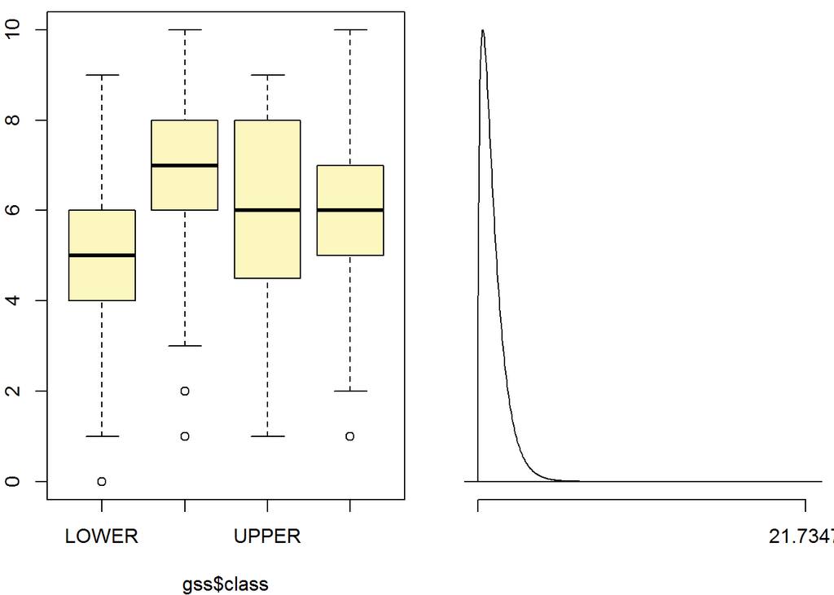

Which of the following methods is appropriate for testing for a difference between the average vocabulary test scores among the various social classes?

answer: c

View the p-values of the pairwise tests from the ANOVA output. Which of the following pairs of means are concluded to be different at the modified significance level?

1. Middle and lower
2. Working and lower
3. Middle and upper
4. Working and upper
5. Upper and lower

answer: a